# Lab Assignment Six: Convolutional Network Architectures

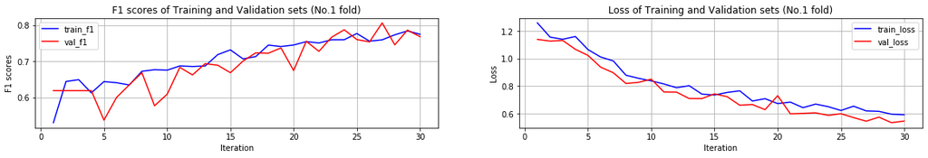

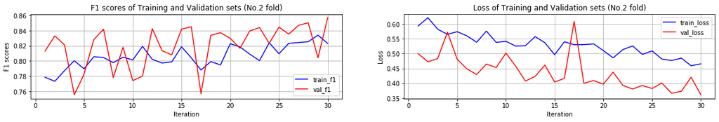

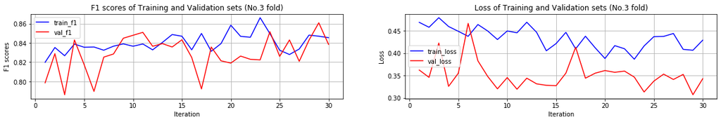

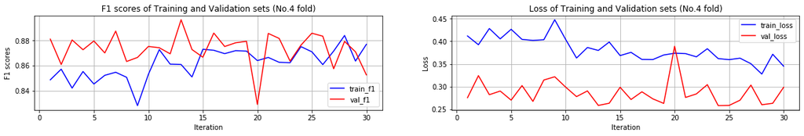

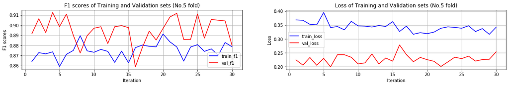

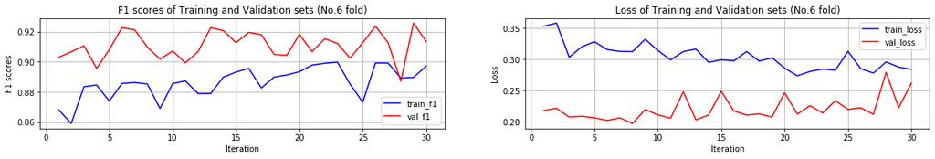

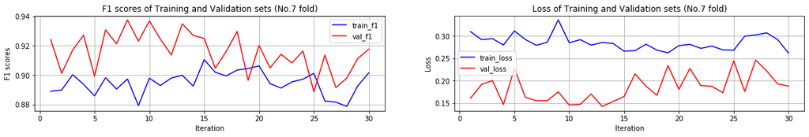

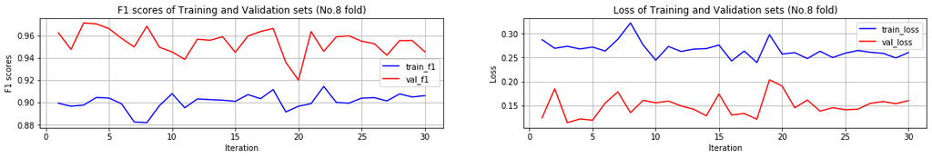

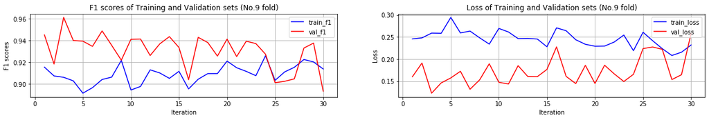

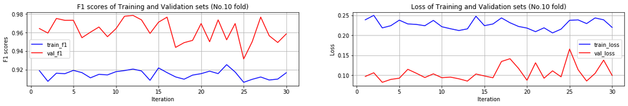

```python
# there are 10 folds, so there are 10 groups of data
for i in range(0, len(cv_training_f1_score)):
    iteration = range(1,len(cv_training_f1_score[i])+1)
    plt.figure(figsize=(20,30))

    plt.subplot(10,2,1)
    plt.plot(iteration, cv_training_f1_score[i], linestyle='-', color='blue', label='train_f1')
    plt.plot(iteration, cv_val_f1_score[i], linestyle='-', color='red', label='val_f1')
    plt.grid()
    plt.legend()
    plt.xlabel('Iteration')
    plt.ylabel('F1 scores')
    plt.title('F1 scores of Training and Validation sets (No.%.0f fold)' % (i+1))

    plt.subplot(10,2,2)
    plt.plot(iteration, cv_training_loss[i], linestyle='-', color='blue', label='train_loss')
    plt.plot(iteration, cv_val_loss[i], linestyle='-', color='red', label='val_loss')
    plt.grid()
    plt.legend()
    plt.xlabel('Iteration')
    plt.ylabel('Loss')
    plt.title('Loss of Training and Validation sets (No.%.0f fold)' % (i+1))
```

#### 2.3 Visualize the final results of the CNNs and interpret the performance. Use proper statistics as appropriate, especially for comparing models.

```python
from sklearn import metrics as mt
from skimage.io import imshow
%matplotlib inline

def summarize_net(net, X_test, y_test, title_text=''):
    plt.figure(figsize=(15,5))
    yhat = np.argmax(net.predict(X_test), axis=1)
    f1_score = mt.f1_score(y_test,yhat,average ='micro')
    cm = mt.confusion_matrix(y_test,yhat)
    cm = cm/np.sum(cm,axis=1)[:,np.newaxis]
    sns.heatmap(cm, annot=True, fmt='.2f')
    plt.title(title_text+'{:.4f}'.format(f1_score))
    return f1_score, y_test, yhat
```

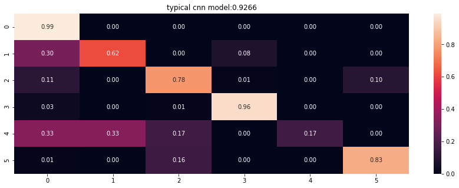

```python
f1_score, y_test, yhat = summarize_net(cnn, X_test, y_test,title_text='typical cnn model:')
```

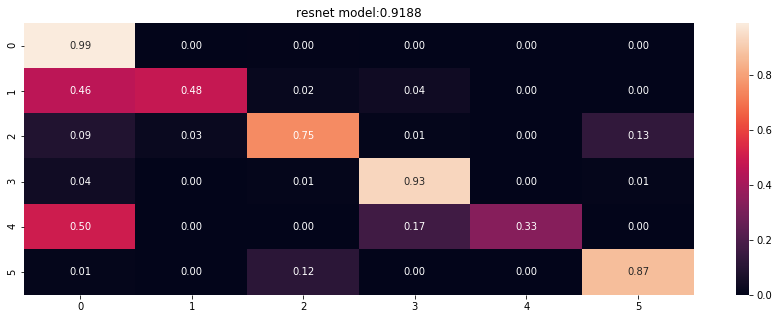

```python
f1_score, y_test, yhat = summarize_net(resnet, X_test, y_test,title_text='resnet model:')
```

Resnet does poor job when class = 1 and 4

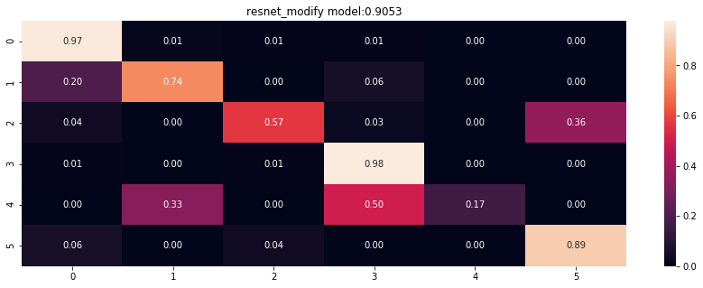

```python
f1_score, y_test, yhat = summarize_net(resnet_modify, X_test, y_test,title_text='resnet_modify model:')
```

resnet_modify model does poor job when class = 4, but does better than resnet when class =1

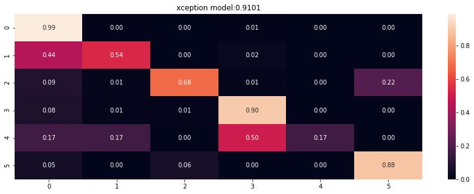

```python
f1_score, y_test, yhat = summarize_net(xception_model, X_test, y_test,title_text='xception model:')
```

xception model do poor job when class = 4.

F1 comparion: typical cnn 0.9266> resnet 0.9188> Xception_model 0.9101> resnet modify 0.9053. However, as for time, typical cnn takes the longest time among 4 models. And resnet, resnet_modify, xception_model they all perform bad when class =4.

### McNemar comparsion

```python
pred1 = cnn.predict(X_train)
pred2 = resnet.predict(X_train)
pred3 = xception_model.predict(X_train)
pred4 = resnet_modify.predict(X_train)
```

```python
pred1.astype(int)
pred2.astype(int)
pred3.astype(int)
pred4.astype(int)
```

```
array([[0, 0, 0, 0, 0, 0],
       [0, 0, 0, 0, 0, 0],
       [0, 0, 0, 0, 0, 0],
       ...,
       [0, 0, 0, 0, 0, 0],
       [0, 0, 0, 0, 0, 0],
       [0, 0, 0, 0, 0, 0]])
```

```python
data1 = [np.argmax(one_hot)for one_hot in pred1]
data2 = [np.argmax(one_hot)for one_hot in pred2]
data3 = [np.argmax(one_hot)for one_hot in pred3]
data4 = [np.argmax(one_hot)for one_hot in pred4]
data1 = np.array(data1)
data2 = np.array(data2)
data3 = np.array(data3)
data4 = np.array(data4)
y_train = np.array(y_train)
```

### typical cnn vs resnet

```python
from mlxtend.evaluate import mcnemar_table
```

```python
table1 = mcnemar_table(y_target=y_train,
                   y_model1=data1,
                   y_model2=data2)
print(table1)
```

```
[[3987   89]
 [  37   24]]
```

```python
from mlxtend.evaluate import mcnemar

chi, p = mcnemar(ary=table1, exact=True)

print('chi-squared:', chi)
print('p-value:', p)
```

```
chi-squared: 37
p-value: 4.099291097200168e-06
```

### typical vs xcpetion model

```python
table2 = mcnemar_table(y_target=y_train,
                   y_model1=data1,
                   y_model2=data3)
print(table2)
```

```
[[3914   84]
 [ 110   29]]
```

```python
from mlxtend.evaluate import mcnemar

chi, p = mcnemar(ary=table2, exact=True)

print('chi-squared:', chi)
print('p-value:', p)
```

```
chi-squared: 84
p-value: 0.07239685103568659
```

### xception model vs resnet model

```python
table3 = mcnemar_table(y_target=y_train,
                   y_model1=data2,
                   y_model2=data3)
print(table3)
```

```
[[3981   17]
 [  95   44]]
```

```python
from mlxtend.evaluate import mcnemar

chi, p = mcnemar(ary=table3, exact=True)

print('chi-squared:', chi)
print('p-value:', p)
```

```
chi-squared: 17
p-value: 2.5077297681380093e-14
```

Since the p-value is less than our assumed significance threshold (α=0.05), we reject our null hypothesis and assume that there is significant difference between the resnet and xception model.

### resnet model vs resnet modify model

```python
table4 = mcnemar_table(y_target=y_train,
                   y_model1=data2,
                   y_model2=data4)
print(table3)
```

```
[[3981   17]
 [  95   44]]
```

```python
from mlxtend.evaluate import mcnemar

chi, p = mcnemar(ary=table4, exact=True)

print('chi-squared:', chi)
print('p-value:', p)
```

```
chi-squared: 27
p-value: 3.8120988823242364e-19
```

Since the p-value is less than our assumed significance threshold (α=0.05), we reject our null hypothesis and assume that there is significant difference between the resnet and resnet_modify model. Maybe changing the size of kenerl size influence a lot.

## 2.4 Compare the performance of your convolutional network to a standard multi-layer perceptron (MLP) using the receiver operating characteristic and area under the curve. Use proper statistical comparison techniques.

### MLP

```python
from keras.models import Sequential
from keras.layers.core import Dense, Dropout, Activation
from keras.optimizers import SGD
from sklearn.metrics import roc_curve, auc

X_train_mlp, X_test_mlp, y_train_mlp, y_test_mlp = train_test_split(X, y, test_size=0.2, shuffle=True, stratify=y)
X_train_mlp = preprocessing.normalize(X_train_mlp)
X_test_mlp = preprocessing.normalize(X_test_mlp)

y_train_ohe_mlp = keras.utils.to_categorical(y_train_mlp, NUM_CLASSES)
y_test_ohe_mlp = keras.utils.to_categorical(y_test_mlp, NUM_CLASSES)
# This returns a tensor
inputs = Input(shape=(X_train_mlp.shape[1],))

# a layer instance is callable on a tensor, and returns a tensor
x = Dense(units=200, activation='relu')(inputs)
x = Dense(units=100, activation='tanh')(x)
x = Dense(units=50, activation='tanh')(x)
x = Dense(units=25, activation='tanh')(x)
x = Dense(units=10, activation='tanh')(x)
predictions = Dense(6,activation='softmax')(x)

# This creates a model that includes
# the Input layer and three Dense layers
mlp = Model(inputs=inputs, outputs=predictions)
```

```python
mlp.compile(loss='mean_squared_error',
              optimizer='rmsprop',
              metrics=[f1])
mlp.fit(X_train_mlp, y_train_ohe_mlp,
        batch_size=128, epochs=30, validation_data=(X_test_mlp, y_test_ohe_mlp),
        shuffle=True, verbose=1)
```

```
Train on 4137 samples, validate on 1035 samples
```

```
<keras.callbacks.callbacks.History at 0x203b4842808>
```

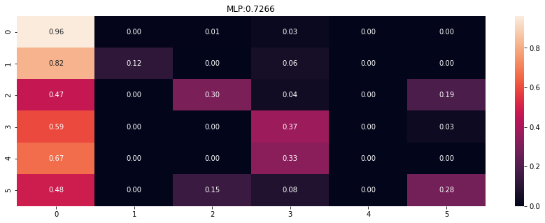

```python
f1_score, y_test, yhat = summarize_net(mlp, X_test_mlp, y_test_mlp,title_text='MLP:')
```

From the compare matrix, we could tell that multi layer perceptron model only does great job when class = 0(when bee is healthy), for the other classes, MLp has worse performance.

### ROC

```python
from keras.utils import np_utils
def plotROC(X,Y,model,name):
    y_score =model.predict(X)
    y_t=Y

    fpr = dict()
    tpr = dict()
    roc_auc = dict()
    for j in range(NUM_CLASSES):
        fpr[j], tpr[j], _ = roc_curve(y_t[:, j], y_score[:, j])
        roc_auc[j] = auc(fpr[j], tpr[j])

    # Compute micro-average ROC curve and ROC area
    fpr["micro"], tpr["micro"], _ = roc_curve(y_t.ravel(), y_score.ravel())
    roc_auc["micro"] = auc(fpr["micro"], tpr["micro"])

    plt.plot(fpr[2], tpr[2],
             lw=1, label='model %s ROC curve (area = %0.2f)' % (name,roc_auc[2]))

    plt.plot([0, 1], [0, 1], color='navy', lw=2, linestyle='--')
    plt.xlim([0.0, 1.0])
    plt.ylim([0.0, 1.05])
    plt.xlabel('False Positive Rate')
    plt.ylabel('True Positive Rate')
    plt.title('Receiver operating characteristic example')
    plt.legend(loc="lower right")
```

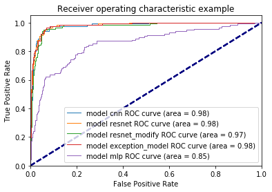

```python
plotROC(X_test,y_test_ohe,cnn,'cnn')
plotROC(X_test,y_test_ohe,resnet,'resnet')
plotROC(X_test,y_test_ohe,resnet_modify,'resnet_modify')
plotROC(X_test,y_test_ohe,xception_model,'exception_model')
plotROC(X_test_mlp,y_test_ohe_mlp,mlp,'mlp')
plt.show()
```

From the Roc curve, we can campare these models by the under curve area. it is obvious that mlp has the least area, and resnet_modify has second least area = 0.97. The other three looks close to each other. Typical cnn, resnet, xception they all have large under carve area = 0.98.

## Exceptional Work

Use transfer learning to pre-train the weights of your initial layers of your CNN. Compare the performance when using transfer learning to training from scratch in terms of classification performance.

Citation:https://towardsdatascience.com/transfer-learning-from-pre-trained-models-f2393f124751

Transfer learning is a popular method in computer vision because it allows us to build accurate models in a timesaving way (Rawat & Wang 2017). With transfer learning, instead of starting the learning process from scratch, you start from patterns that have been learned when solving a different problem. This way you leverage previous learnings and avoid starting from scratch. Take it as the deep learning version of Chartres’ expression ‘standing on the shoulder of giants’.  
In computer vision, transfer learning is usually expressed through the use of pre-trained models. A pre-trained model is a model that was trained on a large benchmark dataset to solve a problem similar to the one that we want to solve. Accordingly, due to the computational cost of training such models, it is common practice to import and use models from published literature (e.g. VGG, Inception, MobileNet). A comprehensive review of pre-trained models’ performance on computer vision problems using data from the ImageNet (Deng et al. 2009) challenge is presented by Canziani et al. (2016).

```python
from keras.applications.resnet50 import ResNet50
from keras.preprocessing import image
from keras.applications.resnet50 import preprocess_input, decode_predictions
import numpy as np
```

```python
X_train, X_test, y_train, y_test = train_test_split(X, y, test_size=0.2,
                                                   random_state=20, stratify=y)

X_train = preprocessing.normalize(X_train)
X_test = preprocessing.normalize(X_test)

print(X_train.shape)
print(X_test.shape)

X_train = np.expand_dims(X_train.reshape((-1,img_wh,img_wh)), axis=3)
X_test = np.expand_dims(X_test.reshape((-1,img_wh,img_wh)), axis=3)

y_train_ohe = keras.utils.to_categorical(y_train, NUM_CLASSES)
y_test_ohe = keras.utils.to_categorical(y_test, NUM_CLASSES)

print(X_train.shape)
print(X_test.shape)
```

```
(4137, 6084)
(1035, 6084)
(4137, 78, 78, 1)
(1035, 78, 78, 1)
```

```python
from skimage.transform import resize
import numpy as np
import skimage

# convert the gray scale image to rgb (3 channels)

x_train_up = [skimage.color.gray2rgb(np.resize(x, (78,78)))
              for x in X_train]
x_train_up = np.stack(x_train_up, axis=0)
print(x_train_up.shape)

x_test_up = [skimage.color.gray2rgb(np.resize(x, (78,78)))
             for x in X_test]
x_test_up = np.stack(x_test_up, axis=0)
print(x_test_up.shape)
```

```
(4137, 78, 78, 3)
(1035, 78, 78, 3)
```

We choose ResNet50 as our pre-trained network here.

```python
from keras.applications.resnet50 import ResNet50
from keras.applications.resnet50 import preprocess_input, decode_predictions


res = ResNet50(weights='imagenet', include_top=False)

x = x_train_up[0]
x = np.expand_dims(x, axis=0)
x = preprocess_input(x)

preds = res.predict(x)
preds.shape
```

```
(1, 3, 3, 2048)
```

```python
x_train_up = preprocess_input(x_train_up)
x_test_up = preprocess_input(x_test_up)
```

```python
%%time

# train on half the data, to save a few hours
x_train_resnet = res.predict(x_train_up)
x_test_resnet = res.predict(x_test_up)
print(x_train_resnet.shape)
```

```
(4137, 3, 3, 2048)
Wall time: 1min 29s
```

```python
print(x_test_resnet.shape)
```

```
(1035, 3, 3, 2048)
```

After pre-train our dataset, we add it into fully connected layer.

```python
input_x = Input(shape=x_train_resnet[0].shape)
x = Dropout(0.25)(input_x)
x = Flatten()(x)
x = Dense(128, activation='relu')(x)
x = Dropout(0.5)(x)
x = Dense(128, activation='relu')(x)
# and a fully connected layer
predictions = Dense(NUM_CLASSES, activation='softmax', kernel_initializer='glorot_uniform')(x)

model = Model(inputs=input_x, outputs=predictions)

model.summary()
```

```
Model: "model_3"
_________________________________________________________________
Layer (type)                 Output Shape              Param #
=================================================================
input_5 (InputLayer)         (None, 3, 3, 2048)        0
_________________________________________________________________
dropout_11 (Dropout)         (None, 3, 3, 2048)        0
_________________________________________________________________
flatten_6 (Flatten)          (None, 18432)             0
_________________________________________________________________
dense_11 (Dense)             (None, 128)               2359424
_________________________________________________________________
dropout_12 (Dropout)         (None, 128)               0
_________________________________________________________________
dense_12 (Dense)             (None, 128)               16512
_________________________________________________________________
dense_13 (Dense)             (None, 6)                 774
=================================================================
Total params: 2,376,710
Trainable params: 2,376,710
Non-trainable params: 0
_________________________________________________________________
```

```python
y_train_ohe_resnet = y_train_ohe[:x_train_resnet.shape[0]]
y_test_ohe_resnet = y_test_ohe[:x_test_resnet.shape[0]]
model.compile(optimizer='rmsprop', loss='categorical_crossentropy',metrics=[f1])

history_resnet = model.fit(x_train_resnet,y_train_ohe_resnet,epochs=30,
          batch_size=32,verbose=1,
         validation_data=(x_test_resnet, y_test_ohe_resnet))
```

```
Train on 4137 samples, validate on 1035 samples
```

```python
y_test_resnet = [np.argmax(one_hot)for one_hot in y_test_ohe_resnet]
```

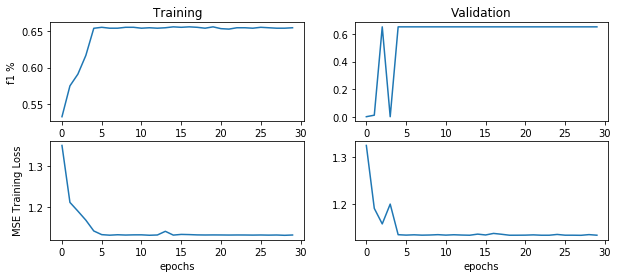

```python
from matplotlib import pyplot as plt

%matplotlib inline

plt.figure(figsize=(10,4))
plt.subplot(2,2,1)
plt.plot(history_resnet.history['f1'])

plt.ylabel('f1 %')
plt.title('Training')
plt.subplot(2,2,2)
plt.plot(history_resnet.history['val_f1'])
plt.title('Validation')

plt.subplot(2,2,3)
plt.plot(history_resnet.history['loss'])
plt.ylabel('MSE Training Loss')
plt.xlabel('epochs')

plt.subplot(2,2,4)
plt.plot(history_resnet.history['val_loss'])
plt.xlabel('epochs')
```

```python
history_resnet_origin= resnet.fit_generator(datagen.flow(X_train, y_train_ohe, batch_size=128),
                   steps_per_epoch=int(len(X_train)/128), # how many generators to go through per epoch
                   epochs=30, verbose=1,
                   validation_data=(X_test,y_test_ohe)
                  )
```

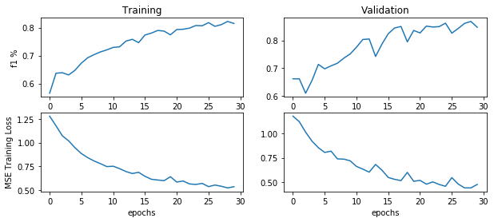

```python
from matplotlib import pyplot as plt

%matplotlib inline

plt.figure(figsize=(10,4))
plt.subplot(2,2,1)
plt.plot(history_resnet_origin.history['f1'])

plt.ylabel('f1 %')
plt.title('Training')
plt.subplot(2,2,2)
plt.plot(history_resnet_origin.history['val_f1'])
plt.title('Validation')

plt.subplot(2,2,3)
plt.plot(history_resnet_origin.history['loss'])
plt.ylabel('MSE Training Loss')
plt.xlabel('epochs')

plt.subplot(2,2,4)
plt.plot(history_resnet_origin.history['val_loss'])
plt.xlabel('epochs')
```

# Performance comparison

### Runing Time

After using transfer learning, our processed model run way faster than original non-processed resnet model. for the original non-processed resnet model, implementing every epoch takes around 18 seconds. However for the processed model, it only takes around 3 seconds to run each epoch, Which strongly proved that the model adopting tranfer learning in advance would improve the speed of implementing convolution neural network.

### Metries of the models

For original non-processed model. From the line chart of model metrics(f1 and MSE), we could tell that for original non-processed model, either for training dataset or for validation dataset. It takes about 20 epochs to to get the flatten point, and there are many up and downs showed in the chart, which means the original model is not very stable. The f1 scores of the model for both training and validation dataset are pretty high, they are both above 80%.

For processed model. From the line chart of model metrics(f1 and MSE), we could tell that for processed model, either for training dataset or for validation dataset. It takes about 5 epochs to to get the flatten point, and there are very few up and downs showed in the chart,which means the processed model is more stable than the original one. The f1 scores of the model for both training and validation dataset are above 60%, which are not as good as the original non-processed model.

Based on our practice, we could tell that if you want much faster speed and not longing for better model performance, you oculd choose model adopting transfer learning in advance. However, if you want higher performance of model and not caring much about the running speed, you could still use non-proceed CNN model.